# Interpretation and Analysis of the FIP Matrix

PARC-HBM and PARCToxicology as FAIR Implementing Communities

Viviane Girardin

29 juni 2026

# 1 Background

Through a **FAIR Implementation Profile (FIP)**, a **FAIR Implementing Community (FIC)** declares the **FAIR Enabling Resources (FERs)** (standards, identifiers, protocols, vocabularies, licences, etc) that it uses to address the FAIR principles. The FIP is built around **21 questions** derived from the **14 FAIR principles** (Findable, Accessible, Interoperable, Reusable). A **FIP matrix** places two or more FICs side by side so their FER choices can be compared.

This report interprets a FIP matrix for two FICs within the **PARC** project:

- **PARC-HBM** — Human Biomonitoring
- **PARCToxicology**

These were the only FICs related to PARC found in https://fip-matrix.streamlit.app/.

For each FER, both FICs are scored on a **0–3 scale**:

**Scoring legend (0–3 scale)**

Scoring legend used throughout this report

| Score | Meaning |
| --- | --- |
| 0 | No data |
| 1 | Resource in development / future use |
| 2 | Available resource / future use |
| 3 | Available resource / current use |

# 2 Data Overview

**High-level overview**

High-level overview of the FIP matrix

| Metric | Value |
| --- | --- |
| Total matrix rows (FER × question) | 51 |
| Distinct FERs | 35 |
| Distinct FIP questions | 18 |
| FAIR principles covered | 4 |

The matrix is organised by FAIR principle. The table below shows how many rows fall under each principle and whether they target **Data** or **Metadata**.

**Rows by FAIR principle and target**

Number of matrix rows by FAIR principle and target

| Principle | Data | General | Metadata |
| --- | --- | --- | --- |
| Findable | 3 | 6 | 3 |
| Accessible | 5 | 1 | 5 |
| Interoperable | 5 | 0 | 14 |
| Reusable | 3 | 0 | 6 |

# 3 Summary Statistics per FIC

The matrix is reshaped into long form so the two FICs can be compared directly.

**Score distribution per FIC**

Distribution of scores per FIC

| Community | No data | Available / future | Available / current | In development |
| --- | --- | --- | --- | --- |
| PARC-HBM | 25 | 13 | 13 | 0 |
| PARCToxicology | 23 | 15 | 12 | 1 |

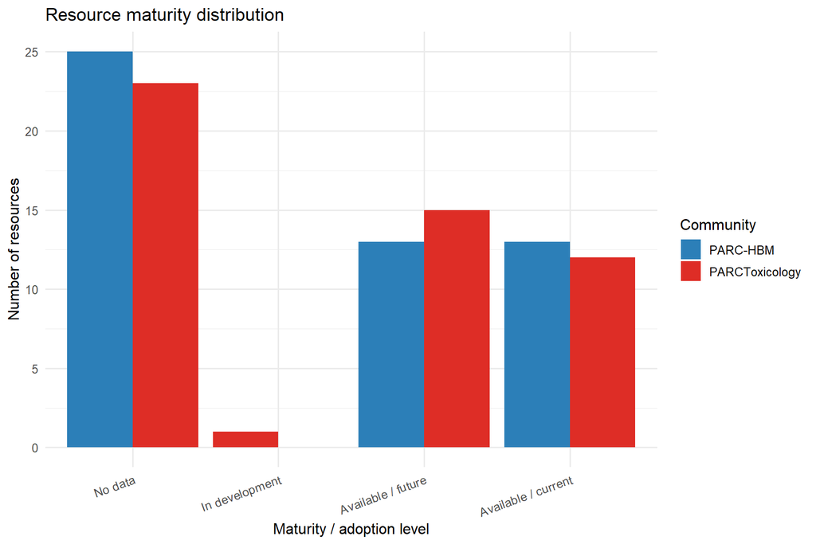

Distribution of maturity scores by community.

**Score summary per FIC**

Score summary per FIC

| Community | Mean score | No data (0) | In development (1) | Available, future (2) | Available, current (3) | Currently in use (3) % |
| --- | --- | --- | --- | --- | --- | --- |
| PARC-HBM | 1.27 | 25 | 0 | 13 | 13 | 25.5% |
| PARCToxicology | 1.31 | 23 | 1 | 15 | 12 | 23.5% |

# 4 The FIP Matrix as a Heatmap

In the heatmap below each cell is a FER, with colour showing its score for each FIC. FERs are grouped by FAIR principle.

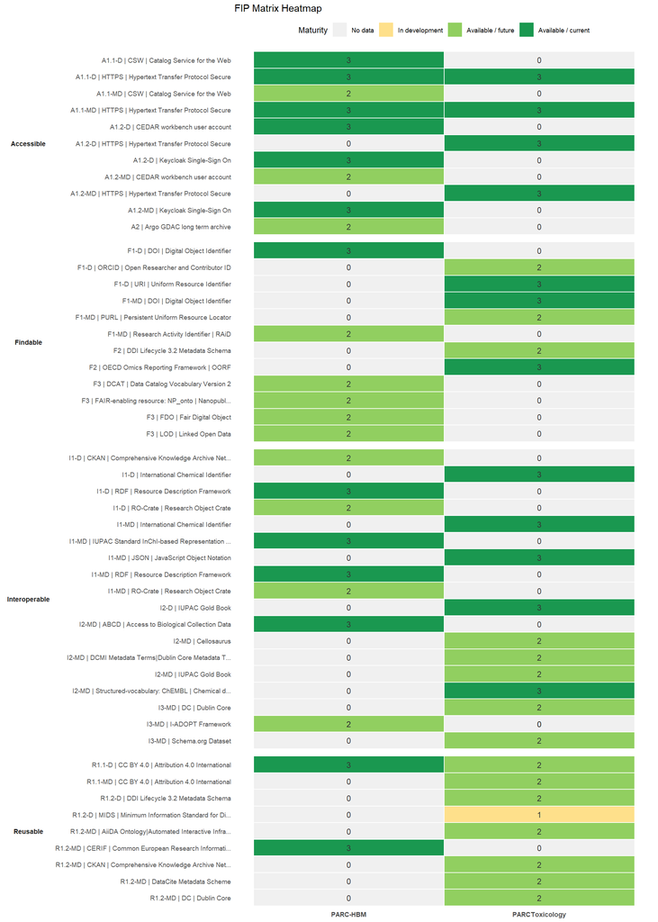

FIP matrix heatmap. Rows are resources (grouped by FAIR principle); columns are communities; colour encodes maturity.

# 5 Comparison Between the Two FICs

For every FER, the two FICs are compared and the relationship classified as shared, specific to one FIC, emerging, or absent from both.

**Relationship counts per FER**

Relationship between the two FICs, per FER

| status | Resources |
| --- | --- |
| Tox-only strength | 24 |
| HBM-only strength | 23 |
| Shared / aligned | 3 |
| Emerging (in development) | 1 |

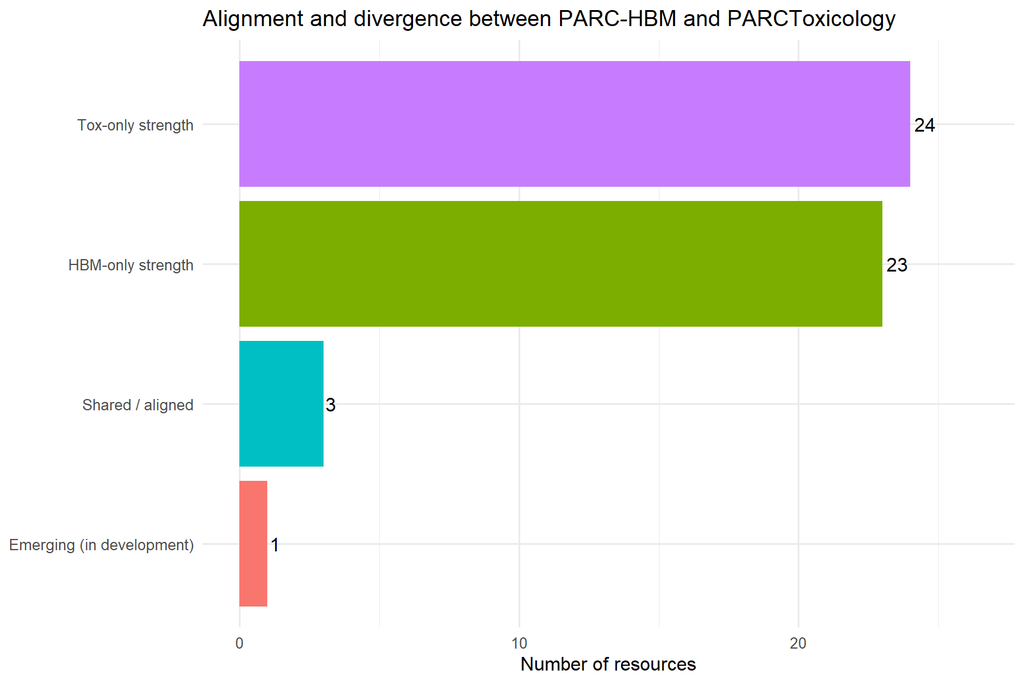

Number of resources by community-relationship category.

## 5.1 FERs shared by both FICs

**FERs shared by both FICs**

FERs available to both FICs (score >= 2 each)

| FIP_question | Principle | Resource | PARC_HBM | PARC_Tox |
| --- | --- | --- | --- | --- |
| A1.1-D | Accessible | HTTPS \| Hypertext Transfer Protocol Secure | 3 | 3 |
| A1.1-MD | Accessible | HTTPS \| Hypertext Transfer Protocol Secure | 3 | 3 |
| R1.1-D | Reusable | CC BY 4.0 \| Attribution 4.0 International | 3 | 2 |

# 6 Coverage by FAIR Principle

The mean score per principle shows which FAIR dimensions each FIC supports best.

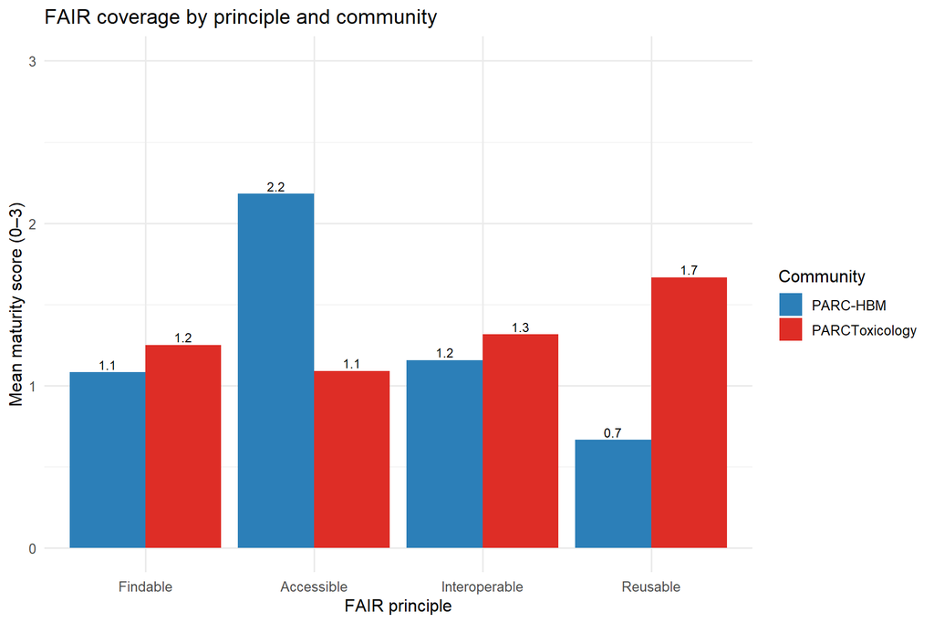

**Mean score per FAIR principle**

Mean maturity score per FAIR principle

| Principle | PARC-HBM | PARCToxicology |
| --- | --- | --- |
| Findable | 1.08 | 1.25 |
| Accessible | 2.18 | 1.09 |
| Interoperable | 1.16 | 1.32 |
| Reusable | 0.67 | 1.67 |

# 7 Data vs. Metadata

Many FIP questions are declared separately for **Data (-D)** and **Metadata (-MD)**. Comparing the two shows whether each FIC supports its data and metadata to a similar degree.

**Data vs. Metadata mean scores**

Mean maturity for Data vs. Metadata targets

| Community | Data | Metadata |
| --- | --- | --- |
| PARC-HBM | 1.56 | 1.07 |
| PARCToxicology | 1.38 | 1.43 |

# 8 Interpretation and Key Findings

As long as the FERs are not fully machine-actionable and FAIR, these differences in FER choice are worth documenting: they mark the points where re-use of (meta)data between the two FICs would need a case-by-case check or an agreed mapping.

# 9 Appendix

## 9.1 FERs specific to one FIC

FERs available in one FIC but not the other (score >= 2 in one, < 2 in the other). Because a score of 0 means “no data”, some of these gaps may reflect missing declarations rather than a deliberate difference in FER use.

**FERs specific to one FIC**

FERs available in one FIC but not the other

| FIP_question | Principle | Resource | PARC_HBM | PARC_Tox | status |
| --- | --- | --- | --- | --- | --- |
| A1.1-D | Accessible | CSW \| Catalog Service for the Web | 3 | 0 | HBM-only strength |
| A1.1-MD | Accessible | CSW \| Catalog Service for the Web | 2 | 0 | HBM-only strength |
| A1.2-D | Accessible | CEDAR workbench user account | 3 | 0 | HBM-only strength |
| A1.2-D | Accessible | Keycloak Single-Sign On | 3 | 0 | HBM-only strength |
| A1.2-MD | Accessible | CEDAR workbench user account | 2 | 0 | HBM-only strength |
| A1.2-MD | Accessible | Keycloak Single-Sign On | 3 | 0 | HBM-only strength |
| A2 | Accessible | Argo GDAC long term archive | 2 | 0 | HBM-only strength |
| F1-D | Findable | DOI \| Digital Object Identifier | 3 | 0 | HBM-only strength |
| F1-MD | Findable | Research Activity Identifier \| RAiD | 2 | 0 | HBM-only strength |
| F3 | Findable | DCAT \| Data Catalog Vocabulary Version 2 | 2 | 0 | HBM-only strength |
| F3 | Findable | FAIR-enabling resource: NP_onto \| Nanopublication Ontology | 2 | 0 | HBM-only strength |
| F3 | Findable | FDO \| Fair Digital Object | 2 | 0 | HBM-only strength |
| F3 | Findable | LOD \| Linked Open Data | 2 | 0 | HBM-only strength |
| I1-D | Interoperable | CKAN \| Comprehensive Knowledge Archive Network | 2 | 0 | HBM-only strength |
| I1-D | Interoperable | RDF \| Resource Description Framework | 3 | 0 | HBM-only strength |
| I1-D | Interoperable | RO-Crate \| Research Object Crate | 2 | 0 | HBM-only strength |
| I1-MD | Interoperable | RDF \| Resource Description Framework | 3 | 0 | HBM-only strength |
| I1-MD | Interoperable | RO-Crate \| Research Object Crate | 2 | 0 | HBM-only strength |
| I1-MD | Interoperable | IUPAC Standard InChI-based Representation of Chemical Reactions | 3 | 0 | HBM-only strength |
| I2-MD | Interoperable | ABCD \| Access to Biological Collection Data | 3 | 0 | HBM-only strength |
| I3-MD | Interoperable | I-ADOPT Framework | 2 | 0 | HBM-only strength |
| I3-MD | Interoperable | I-ADOPT Framework | 2 | 0 | HBM-only strength |
| R1.2-MD | Reusable | CERIF \| Common European Research Information Format | 3 | 0 | HBM-only strength |
| A1.2-D | Accessible | HTTPS \| Hypertext Transfer Protocol Secure | 0 | 3 | Tox-only strength |
| A1.2-MD | Accessible | HTTPS \| Hypertext Transfer Protocol Secure | 0 | 3 | Tox-only strength |
| F1-D | Findable | ORCID \| Open Researcher and Contributor ID | 0 | 2 | Tox-only strength |
| F1-D | Findable | URI \| Uniform Resource Identifier | 0 | 3 | Tox-only strength |
| F1-MD | Findable | DOI \| Digital Object Identifier | 0 | 3 | Tox-only strength |
| F1-MD | Findable | PURL \| Persistent Uniform Resource Locator | 0 | 2 | Tox-only strength |
| F2 | Findable | DDI Lifecycle 3.2 Metadata Schema | 0 | 2 | Tox-only strength |
| F2 | Findable | OECD Omics Reporting Framework \| OORF | 0 | 3 | Tox-only strength |
| I1-D | Interoperable | International Chemical Identifier | 0 | 3 | Tox-only strength |
| I1-MD | Interoperable | International Chemical Identifier | 0 | 3 | Tox-only strength |
| I1-MD | Interoperable | JSON \| JavaScript Object Notation | 0 | 3 | Tox-only strength |
| I2-D | Interoperable | IUPAC Gold Book | 0 | 3 | Tox-only strength |
| I2-MD | Interoperable | IUPAC Gold Book | 0 | 2 | Tox-only strength |
| I2-MD | Interoperable | Cellosaurus | 0 | 2 | Tox-only strength |
| I2-MD | Interoperable | DCMI Metadata Terms\|Dublin Core Metadata Terms | 0 | 2 | Tox-only strength |
| I2-MD | Interoperable | Structured-vocabulary: ChEMBL \| Chemical database of the European Molecular Biology Laboratory | 0 | 3 | Tox-only strength |
| I3-MD | Interoperable | DC \| Dublin Core | 0 | 2 | Tox-only strength |
| I3-MD | Interoperable | Schema.org Dataset | 0 | 2 | Tox-only strength |
| R1.1-MD | Reusable | CC BY 4.0 \| Attribution 4.0 International | 0 | 2 | Tox-only strength |
| R1.2-D | Reusable | DDI Lifecycle 3.2 Metadata Schema | 0 | 2 | Tox-only strength |
| R1.2-MD | Reusable | CKAN \| Comprehensive Knowledge Archive Network | 0 | 2 | Tox-only strength |
| R1.2-MD | Reusable | DC \| Dublin Core | 0 | 2 | Tox-only strength |
| R1.2-MD | Reusable | AiiDA Ontology\|Automated Interactive Infrastructure and Database for Computational Science Ontology | 0 | 2 | Tox-only strength |
| R1.2-MD | Reusable | DataCite Metadata Scheme | 0 | 2 | Tox-only strength |

## 9.2 Full matrix

**Complete FIP matrix (all 51 rows)**

Complete FIP matrix

| FIP_question | Principle | Target | Resource | PARC_HBM | PARC_Tox | Link |
| --- | --- | --- | --- | --- | --- | --- |
| A1.1-D | Accessible | Data | CSW \| Catalog Service for the Web | 3 | 0 | http://purl.org/np/RAqJyIk27OEWW4hIMR5Q88KQdQOj4BY7sPx4277MjZWOQ |
| A1.1-D | Accessible | Data | HTTPS \| Hypertext Transfer Protocol Secure | 3 | 3 | http://purl.org/np/RAQMemFusa3RG0PhZ7oY9uL-Io2ey339_Moj1zL2jwvTE |
| A1.1-MD | Accessible | Metadata | CSW \| Catalog Service for the Web | 2 | 0 | http://purl.org/np/RAqJyIk27OEWW4hIMR5Q88KQdQOj4BY7sPx4277MjZWOQ |
| A1.1-MD | Accessible | Metadata | HTTPS \| Hypertext Transfer Protocol Secure | 3 | 3 | http://purl.org/np/RAQMemFusa3RG0PhZ7oY9uL-Io2ey339_Moj1zL2jwvTE |
| A1.2-D | Accessible | Data | CEDAR workbench user account | 3 | 0 | https://w3id.org/np/RAMpIfwUqlQmdmFbURsfpBJclbWHA5GmUSVZ2bNWiKm3o |
| A1.2-D | Accessible | Data | HTTPS \| Hypertext Transfer Protocol Secure | 0 | 3 | http://purl.org/np/RAQMemFusa3RG0PhZ7oY9uL-Io2ey339_Moj1zL2jwvTE |
| A1.2-D | Accessible | Data | Keycloak Single-Sign On | 3 | 0 | http://purl.org/np/RAOhpi4pd0_dAOReqbH_p9URwV30ErkyGK775n4lb9VJg |
| A1.2-MD | Accessible | Metadata | CEDAR workbench user account | 2 | 0 | https://w3id.org/np/RAMpIfwUqlQmdmFbURsfpBJclbWHA5GmUSVZ2bNWiKm3o |
| A1.2-MD | Accessible | Metadata | HTTPS \| Hypertext Transfer Protocol Secure | 0 | 3 | http://purl.org/np/RAQMemFusa3RG0PhZ7oY9uL-Io2ey339_Moj1zL2jwvTE |
| A1.2-MD | Accessible | Metadata | Keycloak Single-Sign On | 3 | 0 | http://purl.org/np/RAOhpi4pd0_dAOReqbH_p9URwV30ErkyGK775n4lb9VJg |
| A2 | Accessible | General | Argo GDAC long term archive | 2 | 0 | http://purl.org/np/RA5m0OcAgs1kBJ7hWDj-vP8OrmzefTfTD6W7hgdOvWY0g |
| F1-D | Findable | Data | DOI \| Digital Object Identifier | 3 | 0 | http://purl.org/np/RAVI6ifsFrq3vkzlwYn5-D-x31ORGJEZ8af0DsBfzQprU |
| F1-D | Findable | Data | ORCID \| Open Researcher and Contributor ID | 0 | 2 | http://purl.org/np/RAtIFnvA0nuTJjr4QEBw8j_CNW-8D7xLAC42qLxSZqDMo |
| F1-D | Findable | Data | URI \| Uniform Resource Identifier | 0 | 3 | http://purl.org/np/RA5-OsT0-sjRbcoFEGfOzkrcFtExipMRmoLErzg5QWL7c |
| F1-MD | Findable | Metadata | DOI \| Digital Object Identifier | 0 | 3 | http://purl.org/np/RAVI6ifsFrq3vkzlwYn5-D-x31ORGJEZ8af0DsBfzQprU |
| F1-MD | Findable | Metadata | PURL \| Persistent Uniform Resource Locator | 0 | 2 | http://purl.org/np/RAP2JVnzTTJImG7qQQd7v9u0vu6kDlcGc0006R2S86L6A |
| F1-MD | Findable | Metadata | Research Activity Identifier \| RAiD | 2 | 0 | https://w3id.org/np/RAHeU6AtsrYPso5qluQ6cPJqmMEK7wJo0RuHEBwvMkj9A |
| F2 | Findable | General | DDI Lifecycle 3.2 Metadata Schema | 0 | 2 | http://purl.org/np/RAKk2DMKAucMpTnicHQthFjTU4W86F482XieWKO9VXFO8 |
| F2 | Findable | General | OECD Omics Reporting Framework \| OORF | 0 | 3 | https://w3id.org/np/RA7oEqhLvsM17UUahLaA7MphqTz3YxU6kmXdGMW3-zlf0 |
| F3 | Findable | General | DCAT \| Data Catalog Vocabulary Version 2 | 2 | 0 | http://purl.org/np/RAi3pnoXjWoZ2RjEd6WVLDIyp0oJsHMUx5Au-mPsNEdyo |
| F3 | Findable | General | FAIR-enabling resource: NP_onto \| Nanopublication Ontology | 2 | 0 | https://w3id.org/np/RAM5zmbkctjoWZRFD2EKlKjfcrN5AnJtAN7XjUrIPUcBA |
| F3 | Findable | General | FDO \| Fair Digital Object | 2 | 0 | http://purl.org/np/RAhVYFmbU5PAMmLW3EIir9xrzviG_sg-YcU_3_UR_l7c0 |
| F3 | Findable | General | LOD \| Linked Open Data | 2 | 0 | http://purl.org/np/RAaG3HBFawImbh3dHLK-bJZpEOcblSJUTAZvhaypiMaw4 |
| I1-D | Interoperable | Data | CKAN \| Comprehensive Knowledge Archive Network | 2 | 0 | http://purl.org/np/RA2ZRsIVy0tmN5lKAocqMXxaiBgmMBwPV_J_TC74SYtok |
| I1-D | Interoperable | Data | International Chemical Identifier | 0 | 3 | http://purl.org/np/RAARoMhW12s1fPhGxMXyfEmnammF1BmmDZsL3zqZju4iw |
| I1-D | Interoperable | Data | RDF \| Resource Description Framework | 3 | 0 | http://purl.org/np/RAutRQwoS4d5eLq7eBV1xsnWZ2spDYH4xfhhRzOxSZdhs |
| I1-D | Interoperable | Data | RO-Crate \| Research Object Crate | 2 | 0 | https://w3id.org/np/RAuNTUbG7FqUcN7N-QTuiWIFXDUOUNUJS8fKfJ1LQBymk |
| I1-MD | Interoperable | Metadata | IUPAC Standard InChI-based Representation of Chemical Reactions | 3 | 0 | http://purl.org/np/RAm3fujGbvDzV5iSQb3eWx1elxWu9UQUPsHWtNAbZTa-M |
| I1-MD | Interoperable | Metadata | International Chemical Identifier | 0 | 3 | http://purl.org/np/RAARoMhW12s1fPhGxMXyfEmnammF1BmmDZsL3zqZju4iw |
| I1-MD | Interoperable | Metadata | JSON \| JavaScript Object Notation | 0 | 3 | http://purl.org/np/RAbV2g2AjtbD_n53nwC5B0eERessUJbrZO5PVRzM6ioC8 |
| I1-MD | Interoperable | Metadata | RDF \| Resource Description Framework | 3 | 0 | http://purl.org/np/RAutRQwoS4d5eLq7eBV1xsnWZ2spDYH4xfhhRzOxSZdhs |
| I1-MD | Interoperable | Metadata | RO-Crate \| Research Object Crate | 2 | 0 | https://w3id.org/np/RAuNTUbG7FqUcN7N-QTuiWIFXDUOUNUJS8fKfJ1LQBymk |
| I2-D | Interoperable | Data | IUPAC Gold Book | 0 | 3 | http://purl.org/np/RAQtuJa-bzLqVlxCcWNvR8C1tAtHRO9E1KDeqXCmce4gQ |
| I2-MD | Interoperable | Metadata | ABCD \| Access to Biological Collection Data | 3 | 0 | http://purl.org/np/RANS-bRIhaK8BMWuxGr_lb7a-nPt2O1_ijrPiyNTNe8uI |
| I2-MD | Interoperable | Metadata | Cellosaurus | 0 | 2 | http://purl.org/np/RATt4Su6Nt6dP4JShHtWnxp2s8-lIB-C3qVmoJih2A5nQ |
| I2-MD | Interoperable | Metadata | DCMI Metadata Terms\|Dublin Core Metadata Terms | 0 | 2 | http://purl.org/np/RAtBs7WUCXYRMmdDGKDEwYlyjJCC3bc0KWXTjlfJHiW_E |
| I2-MD | Interoperable | Metadata | IUPAC Gold Book | 0 | 2 | http://purl.org/np/RAQtuJa-bzLqVlxCcWNvR8C1tAtHRO9E1KDeqXCmce4gQ |
| I2-MD | Interoperable | Metadata | Structured-vocabulary: ChEMBL \| Chemical database of the European Molecular Biology Laboratory | 0 | 3 | https://w3id.org/np/RAqMLXyLi3tvYwbnplInCasVa8IaFtuMFKqq9D9_PFEFE |
| I3-MD | Interoperable | Metadata | DC \| Dublin Core | 0 | 2 | http://purl.org/np/RAK3QFfVH3RgiiuQgzFbFwABVhk3Jkjzd1XuATnoOavrA |
| I3-MD | Interoperable | Metadata | I-ADOPT Framework | 2 | 0 | https://w3id.org/np/RA1IL1Imt_mMIo8YIhNsJBvVqOKs71nkfk1fq12U24Q24 |
| I3-MD | Interoperable | Metadata | I-ADOPT Framework | 2 | 0 | https://w3id.org/np/RAX0oWKAswMsjZxM3qLaR65uSnWjHEMoZ0wCxqUE7n3FY |
| I3-MD | Interoperable | Metadata | Schema.org Dataset | 0 | 2 | http://purl.org/np/RAfpqImxNsTJLDAV3ZvcQBOddyZf-Yhl2WHXFpGHOLe-Y |
| R1.1-D | Reusable | Data | CC BY 4.0 \| Attribution 4.0 International | 3 | 2 | http://purl.org/np/RAzrzsRCI_jNEBWXYQf8nfBTvFtE5AuvUGpCMv5yqx2MA |
| R1.1-MD | Reusable | Metadata | CC BY 4.0 \| Attribution 4.0 International | 0 | 2 | http://purl.org/np/RAzrzsRCI_jNEBWXYQf8nfBTvFtE5AuvUGpCMv5yqx2MA |
| R1.2-D | Reusable | Data | DDI Lifecycle 3.2 Metadata Schema | 0 | 2 | http://purl.org/np/RAKk2DMKAucMpTnicHQthFjTU4W86F482XieWKO9VXFO8 |
| R1.2-D | Reusable | Data | MIDS \| Minimum Information Standard for Digital Specimens | 0 | 1 | http://purl.org/np/RAbU1Pg-kRI2F3QhWMONgqzQf9bkDSh4B_SbkLy3d-0UY |
| R1.2-MD | Reusable | Metadata | AiiDA Ontology\|Automated Interactive Infrastructure and Database for Computational Science Ontology | 0 | 2 | http://purl.org/np/RARX6kU4AMDTe-CMOa-mGEG-_cvJNcHiDVXcvxQPq_heA |
| R1.2-MD | Reusable | Metadata | CERIF \| Common European Research Information Format | 3 | 0 | http://purl.org/np/RAtv_q4s-8xxL_is8gV8GPDwoqVY550Omdvy9Rg0Liaqc |
| R1.2-MD | Reusable | Metadata | CKAN \| Comprehensive Knowledge Archive Network | 0 | 2 | http://purl.org/np/RA2ZRsIVy0tmN5lKAocqMXxaiBgmMBwPV_J_TC74SYtok |
| R1.2-MD | Reusable | Metadata | DC \| Dublin Core | 0 | 2 | http://purl.org/np/RAK3QFfVH3RgiiuQgzFbFwABVhk3Jkjzd1XuATnoOavrA |
| R1.2-MD | Reusable | Metadata | DataCite Metadata Scheme | 0 | 2 | http://purl.org/np/RAl80tWl_i_CPaLWi13ofQe3tLCuY74uby1v8VbzfY8_0 |